# Evaluación de Calidad de Vinos (1)

### **⚛️ A. Titulo: Proyecto 2 – Modelos de clasificación supervisada para evaluar la calidad de vinos**

### **⚛️ B. Integrantes**

Jiliar Antonio Silgado Cardona

#### **⭕️ Introducción**

En la industria vinícola, evaluar la calidad de un vino de manera precisa y consistente es crucial tanto para los productores como para los consumidores. Con una gran cantidad de características químicas y sensoriales, el análisis individual de cada vino resulta complejo y poco práctico. Gracias al uso de modelos de machine learning y al análisis de datos, es posible identificar patrones en las características químicas de los vinos que afectan su calidad. Este enfoque permite desarrollar modelos de clasificación supervisada que predicen la calidad de un vino a partir de sus propiedades, optimizando el proceso de evaluación y apoyando decisiones basadas en datos. Variables como la acidez fija, el contenido de azúcar residual, la densidad y el nivel de alcohol, entre otras, se utilizan para crear modelos que puedan clasificar de forma confiable la calidad del producto, mejorando así la eficiencia y precisión en la industria.

#### **⭕️ Núcleo Problémico**

Dado el crecimiento en la producción y demanda de vinos de alta calidad, las bodegas enfrentan el reto de clasificar sus productos de manera eficiente y precisa entre las categorías de vino "blanco" y "tinto". Sin una herramienta confiable para evaluar la calidad del vino a partir de sus propiedades químicas, la clasificación y diferenciación de productos puede volverse inconsistente y subjetiva, afectando la percepción del consumidor y la competitividad en el mercado. En particular, se necesita analizar si existe una relación significativa entre características como la acidez, el contenido de azúcar residual, el nivel de alcohol y otros componentes químicos, y la variable objetivo de clasificación del vino ("class"), que distingue entre vinos "blancos" y "tintos". La ausencia de un modelo predictivo basado en datos dificulta la toma de decisiones informadas sobre el proceso de producción y calidad, limitando la capacidad de la bodega para optimizar sus productos y mejorar su posicionamiento en el mercado. Sin claridad en estas relaciones, la clasificación de los vinos podría depender de criterios poco objetivos, lo cual afectaría la reputación de la marca y la satisfacción del cliente.

#### **⭕️ Pregunta Problemica**

¿Puede un modelo predictivo basado en estas variables mejorar la clasificación de los vinos, proporcionando una evaluación más objetiva y confiable que beneficie la satisfacción del cliente y el posicionamiento en el mercado?

#### **⭕️ Metodología**

1. Un **Pipeline de Regresión Logística con Preprocesamiento Escalar Estándar**, que aplica escalamiento uniforme a las variables numéricas, y
2. Un **Pipeline de Preprocesamiento Mixto utilizando ColumnTransformer**, diseñado para manejar múltiples clases mediante la transformación adecuada de variables categóricas y numéricas.

Finalmente, se analizan los estadísticos de validación para evaluar el rendimiento de los modelos y su capacidad predictiva, lo cual permitirá no solo una clasificación precisa sino también una optimización en la satisfacción del cliente y el posicionamiento en el mercado.

### **🔍 1. Exploración de los datos**

#### **⭕️ Introducción a la Fase de Exploración de Datos**

En esta fase inicial del análisis de datos, se realiza una exploración preliminar del conjunto de datos para comprender su estructura y características básicas. Esta etapa es crucial para identificar los aspectos fundamentales del dataset y preparar el terreno para un análisis más profundo.

Durante la exploración, se utilizan diversas instrucciones para obtener una visión general del conjunto de datos:

### **⭕️ Entendimiento de los datos**

Las bases de datos a utilizar se denominan **`winequality-red.csv`** y **`winequality-white.csv`**. estas contienen información sobre la calidad de vinos tintos y blancos, respectivamente. Ambas bases incluyen diversas características químicas, como acidez fija, acidez volátil, azúcar residual, dióxido de azufre, densidad, pH, sulfatos y contenido de alcohol, además de una variable de calidad que evalúa la percepción del vino en una escala del 0 al 10. Estas bases son fundamentales para analizar y modelar la relación entre las propiedades químicas de los vinos y su calidad.

| Variable | Definición | Descripción | Valores | Tipo de Variable |
| --- | --- | --- | --- | --- |
| fixed acidity | Acidez fija | Medida de la acidez que no se evapora | g/dm³ | Continua |
| volatile acidity | Acidez volátil | Acidez que puede influir en el sabor | g/dm³ | Continua |
| citric acid | Ácido cítrico | Contribuye a la frescura del vino | g/dm³ | Continua |
| residual sugar | Azúcar residual | Cantidad de azúcar que queda tras la fermentación | g/dm³ | Continua |
| chlorides | Cloruros | Compuestos que pueden afectar el sabor | g/dm³ | Continua |
| free sulfur dioxide | Dióxido de azufre libre | Conservante que ayuda a mantener la calidad | mg/dm³ | Continua |
| total sulfur dioxide | Dióxido de azufre total | Total de dióxido de azufre presente | mg/dm³ | Continua |
| density | Densidad | Relación entre masa y volumen | g/cm³ | Continua |
| pH | Acidez | Medida de la acidez del vino | Valor numérico (0-14) | Continua |
| sulphates | Sulfatos | Compuestos que pueden influir en el sabor | g/dm³ | Continua |
| alcohol | Contenido de alcohol | Porcentaje de alcohol en el vino | % vol. | Continua |
| quality | Calidad del vino | Puntuación de calidad asignada por catadores | Escala del 0 al 10 | Discreta |
| class | Clasificación del vino | Tipo de vino, puede ser blanco o tinto | Blanco, Tinto | Cualitativa (nominal) |

```python
# Cargar librerías necesarias para análisis y visualización de datos
import seaborn as sns  # Para visualización de datos en gráficos
import pandas as pd     # Para manipulación de datos utilizando estructuras tipo DataFrame
import numpy as np      # Para operaciones numéricas y manejo de arreglos y matrices
import matplotlib.pyplot as plt  # Para crear gráficos en 2D y visualizar datos
from sklearn.datasets import load_breast_cancer  # Para cargar el conjunto de datos de cáncer de mama
from sklearn.metrics import accuracy_score  # Para evaluar la precisión del modelo
from sklearn.model_selection import train_test_split, GridSearchCV, RandomizedSearchCV  # Para dividir los datos en conjuntos de entrenamiento y prueba
from sklearn.preprocessing import StandardScaler, MinMaxScaler,  OneHotEncoder  # Para escalar características numéricas
from sklearn.linear_model import LogisticRegression  # Para crear un modelo de regresión logística
from sklearn.pipeline import Pipeline  # Para encadenar múltiples pasos de procesamiento y modelado
from sklearn.metrics import confusion_matrix  # Para calcular la matriz de confusión para evaluar el rendimiento del modelo
from sklearn.metrics import classification_report  # Para generar un informe de clasificación que incluye métricas como precisión, recall y f1-score
from sklearn.metrics import accuracy_score #Para el calculo de Exactitud
from sklearn.metrics import precision_score #Para el calculo de Precisión
from sklearn.metrics import recall_score #Para el calculo de Sensibilidad
from sklearn.metrics import f1_score #Para el calculo de Valor F1
from sklearn.metrics import precision_recall_curve # Para generación de curva de precisión Recall
from sklearn.metrics import auc # Para determinar area bajo la curva
from sklearn.metrics import roc_curve # Para generación de curva ROC
from sklearn.impute import SimpleImputer #Para generar Imputadores
from sklearn.compose import ColumnTransformer #para aplicar diferentes transformaciones a diferentes columnas de un DataFrame en un solo paso.
from sklearn.ensemble import RandomForestClassifier # Metodo de entrenamiento del modelo.
from joblib import dump, load # Para la serialización de modelos de machine learning y datos grandes
import random  # Módulo que proporciona funciones para generar números aleatorios y realizar selecciones aleatorias.
import json #Para manipular diccionarios
```

```python
# Lectura de origen de datos:
# Cargar el archivo CSV para vino tinto y especificar el delimitador
df_red = pd.read_csv('../Datos/winequality-red.csv', delimiter=';')

# Agregar una nueva columna 'class' al DataFrame df_red y asignarle el valor 'red'
df_red['class'] = 'red'

# Cargar el archivo CSV para vino blanco y especificar el delimitador
df_white = pd.read_csv('../Datos/winequality-white.csv', delimiter=';')

# Agregar una nueva columna 'class' al DataFrame df_white y asignarle el valor 'white'
df_white['class'] = 'white'

# Unir ambos DataFrames (df_red y df_white) verticalmente en un nuevo DataFrame df
# La opción ignore_index=True reinicia los índices en el DataFrame combinado
df = pd.concat([df_red, df_white], ignore_index=True)

print(f'Forma de Dataframe Vino Rojo{df_red.shape}')
print(f'Forma de Dataframe Vino Rojo{df_white.shape}')
```

```
Forma de Dataframe Vino Rojo(1599, 13)
Forma de Dataframe Vino Rojo(4898, 13)
```

```python
print("Información general del DataFrame:\n")
df.info()
```

```
Información general del DataFrame:

<class 'pandas.core.frame.DataFrame'>
RangeIndex: 6497 entries, 0 to 6496
Data columns (total 13 columns):
 #   Column                Non-Null Count  Dtype
---  ------                --------------  -----
 0   fixed acidity         6497 non-null   float64
 1   volatile acidity      6497 non-null   float64
 2   citric acid           6497 non-null   float64
 3   residual sugar        6497 non-null   float64
 4   chlorides             6497 non-null   float64
 5   free sulfur dioxide   6497 non-null   float64
 6   total sulfur dioxide  6497 non-null   float64
 7   density               6497 non-null   float64
 8   pH                    6497 non-null   float64
 9   sulphates             6497 non-null   float64
 10  alcohol               6497 non-null   float64
 11  quality               6497 non-null   int64
 12  class                 6497 non-null   object
dtypes: float64(11), int64(1), object(1)
memory usage: 660.0+ KB
```

### **⭕️ Diccionario de datos**

Este diccionario de datos proporciona una descripción detallada de las columnas del dataframe obtenido de los archivos **`winequality-red.csv`** y **`winequality-white.csv`**. Cada columna está detallada con su tipo de dato (`Dtype`), una breve descripción del tipo de dato (`Descripción Dtype`), el tamaño en bytes ocupado por el tipo de dato (`Tamaño en Bytes`), y una descripción de los datos representados en esa columna.

El propósito de este diccionario es facilitar la comprensión de la estructura del conjunto de datos y ayudar en el análisis y la manipulación de la información.

**Descripción de las Columnas**

| Column | Dtype | Description Dtype | Tamaño en Bytes | Tamaño en MB | Descripción |
| --- | --- | --- | --- | --- | --- |
| fixed acidity | float64 | Decimal number | 51976 | 0.0496 | Medida de acidez que no se evapora |
| volatile acidity | float64 | Decimal number | 51976 | 0.0496 | Acidez que puede influir en el sabor |
| citric acid | float64 | Decimal number | 51976 | 0.0496 | Contribuye a la frescura del vino |
| residual sugar | float64 | Decimal number | 51976 | 0.0496 | Cantidad de azúcar que queda tras la fermentación |
| chlorides | float64 | Decimal number | 51976 | 0.0496 | Compuestos que pueden afectar el sabor |
| free sulfur dioxide | float64 | Decimal number | 51976 | 0.0496 | Conservante que ayuda a mantener la calidad |
| total sulfur dioxide | float64 | Decimal number | 51976 | 0.0496 | Total de dióxido de azufre presente |
| density | float64 | Decimal number | 51976 | 0.0496 | Relación entre masa y volumen |
| pH | float64 | Decimal number | 51976 | 0.0496 | Medida de la acidez del vino |
| sulphates | float64 | Decimal number | 51976 | 0.0496 | Compuestos que pueden influir en el sabor |
| alcohol | float64 | Decimal number | 51976 | 0.0496 | Porcentaje de alcohol en el vino |
| quality | int64 | Integer number | 51976 | 0.0496 | Puntuación de calidad asignada por catadores |
| class | object | Categorical | 347640 | 0.3311 | Clasificación del vino (blanco o tinto) |

### **⭕️ Dimensiones del Dataframe (Filas x Columnas)**

```python
#Forma del dataframe
print(f'Forma de Dataframe Consolidado de Vinos: {df.shape}')
```

```
Forma de Dataframe Consolidado de Vinos: (6497, 13)
```

#### **⭕️ Primeras filas del DataFrame**

```python
df.head()
```

|  | fixed acidity | volatile acidity | citric acid | residual sugar | chlorides | free sulfur dioxide | total sulfur dioxide | density | pH | sulphates | alcohol | quality | class |
| --- | --- | --- | --- | --- | --- | --- | --- | --- | --- | --- | --- | --- | --- |
| 0 | 7.4 | 0.70 | 0.00 | 1.9 | 0.076 | 11.0 | 34.0 | 0.9978 | 3.51 | 0.56 | 9.4 | 5 | red |
| 1 | 7.8 | 0.88 | 0.00 | 2.6 | 0.098 | 25.0 | 67.0 | 0.9968 | 3.20 | 0.68 | 9.8 | 5 | red |
| 2 | 7.8 | 0.76 | 0.04 | 2.3 | 0.092 | 15.0 | 54.0 | 0.9970 | 3.26 | 0.65 | 9.8 | 5 | red |
| 3 | 11.2 | 0.28 | 0.56 | 1.9 | 0.075 | 17.0 | 60.0 | 0.9980 | 3.16 | 0.58 | 9.8 | 6 | red |
| 4 | 7.4 | 0.70 | 0.00 | 1.9 | 0.076 | 11.0 | 34.0 | 0.9978 | 3.51 | 0.56 | 9.4 | 5 | red |

#### **⭕️ Últimas filas del DataFrame**

```python
# ultimos registros
df.tail()
```

|  | fixed acidity | volatile acidity | citric acid | residual sugar | chlorides | free sulfur dioxide | total sulfur dioxide | density | pH | sulphates | alcohol | quality | class |
| --- | --- | --- | --- | --- | --- | --- | --- | --- | --- | --- | --- | --- | --- |
| 6492 | 6.2 | 0.21 | 0.29 | 1.6 | 0.039 | 24.0 | 92.0 | 0.99114 | 3.27 | 0.50 | 11.2 | 6 | white |
| 6493 | 6.6 | 0.32 | 0.36 | 8.0 | 0.047 | 57.0 | 168.0 | 0.99490 | 3.15 | 0.46 | 9.6 | 5 | white |
| 6494 | 6.5 | 0.24 | 0.19 | 1.2 | 0.041 | 30.0 | 111.0 | 0.99254 | 2.99 | 0.46 | 9.4 | 6 | white |
| 6495 | 5.5 | 0.29 | 0.30 | 1.1 | 0.022 | 20.0 | 110.0 | 0.98869 | 3.34 | 0.38 | 12.8 | 7 | white |
| 6496 | 6.0 | 0.21 | 0.38 | 0.8 | 0.020 | 22.0 | 98.0 | 0.98941 | 3.26 | 0.32 | 11.8 | 6 | white |

#### **⭕️ Tamaño total del DataFrame en términos de número de filas**

```python
# total de registros
total_size = len(df)
print(f'Tamaño (Número de Filas): {total_size}')
```

```
Tamaño (Número de Filas): 6497
```

#### **⭕️ Uso de memoria por columna**

```python
# mostrar el tamaño de la memoria utilizada por el DataFrame
print("Memoria utilizada por el DataFrame (bytes):\n")
print(df.memory_usage(deep=True))
```

```
Memoria utilizada por el DataFrame (bytes):

Index                      132
fixed acidity            51976
volatile acidity         51976
citric acid              51976
residual sugar           51976
chlorides                51976
free sulfur dioxide      51976
total sulfur dioxide     51976
density                  51976
pH                       51976
sulphates                51976
alcohol                  51976
quality                  51976
class                   347640
dtype: int64
```

#### **⭕️ Columnas (Variables) en Dataframe**

```python
# nombres de las columnas
print("\nNombres de las columnas:")
print(df.columns)
```

```
Nombres de las columnas:
Index(['fixed acidity', 'volatile acidity', 'citric acid', 'residual sugar',
       'chlorides', 'free sulfur dioxide', 'total sulfur dioxide', 'density',
       'pH', 'sulphates', 'alcohol', 'quality', 'class'],
      dtype='object')
```

#### **⭕️ Número Total de Variables**

```python
# Número total de variables que contiene la base de datos.
num_columnas = df.shape[1]
print(f'Número de variables (columnas): {num_columnas}')
```

```
Número de variables (columnas): 13
```

#### **⭕️ Variables con datos faltantes, Porcentaje total de valores faltantes en la base de datos.**

```python
import json

def valores_faltantes_por_columna(df):
    # Escribir las variables que tienen datos faltantes, además, proporcionar el porcentaje total de valores faltantes en la base de datos.
    # Paso 1: Encontrar columnas con valores faltantes
    faltantes_por_columna = df.isnull().sum()

    # Paso 2: Filtrar columnas que tienen valores faltantes
    data1 = faltantes_por_columna[faltantes_por_columna > 0]
    variables_con_faltantes = data1.to_dict()

    print('\nCant. valores faltantes por columna:',
          json.dumps(variables_con_faltantes, indent=4),
          sep="\n")

    # Paso 3: Calcular el porcentaje de valores faltantes por columna
    data = (data1 / len(df)) * 100
    data = data.to_dict()
    porcentaje_faltantes_por_columna = {key: f'{value:.2f}%' for key, value in data.items()}

    # Paso 4: Calcular el porcentaje total de valores faltantes en el DataFrame
    porcentaje_total_faltantes = (df.isnull().sum().sum() / df.size) * 100
    porcentaje_total_no_faltantes = (df.notnull().sum().sum() / df.size) * 100

    # Resultados
    print('\n% valores faltantes por columna:', f'{json.dumps(porcentaje_faltantes_por_columna, indent=4)}', sep="\n")

    print(f"\nPorcentaje total de valores faltantes en la base de datos: {porcentaje_total_faltantes:.2f}%")
    print(f"Porcentaje total de valores en la base de datos: {porcentaje_total_no_faltantes:.2f}%")

valores_faltantes_por_columna(df)
```

```
Cant. valores faltantes por columna:
{}

% valores faltantes por columna:
{}

Porcentaje total de valores faltantes en la base de datos: 0.00%
Porcentaje total de valores en la base de datos: 100.00%
```

#### **⭕️ Clasificación de la calidad del vino (`quality`)**

| Calidad | Valor Numérico | Descripción |
| --- | --- | --- |
| Extremadamente baja | 1 | Indica una calidad extremadamente baja, reflejando defectos significativos en el sabor, aroma o apariencia. |
| Inferior | 2 a 3 | Denotan vinos que tienen múltiples imperfecciones o características indeseables. Pueden ser consumidos, pero no recomendados. |
| Media | 4 a 5 | Representan vinos de calidad media, que pueden presentar algunas características agradables, pero también deficiencias. |
| Buena | 6 a 7 | Corresponden a vinos de buena calidad, bien equilibrados en sabor y aroma, disfrutables en reuniones sociales. |
| Superior | 8 a 9 | Reflejan vinos de calidad superior, con un perfil de sabor complejo y atractivo; altamente recomendados para ocasiones especiales. |
| Máxima | 10 | Representa la máxima calidad, indicando un vino excepcional que sobresale en todos los aspectos: aroma, sabor y presentación. |

```python
# Definir una función que asigne descripciones basadas en el valor de quality
def asignar_calidad_desc(valor):
    if valor == 1:
        return "Extremadamente baja"
    elif valor in [2, 3]:
        return "Inferior"
    elif valor in [4, 5]:
        return "Media"
    elif valor in [6, 7]:
        return "Buena"
    elif valor in [8, 9]:
        return "Superior"
    elif valor == 10:
        return "Máxima"
    else:
        return "No definida"

# Aplicar la función para crear la nueva columna quality_desc
df['quality_desc'] = df['quality'].apply(asignar_calidad_desc)

df.head()
```

|  | fixed acidity | volatile acidity | citric acid | residual sugar | chlorides | free sulfur dioxide | total sulfur dioxide | density | pH | sulphates | alcohol | quality | class | quality_desc |
| --- | --- | --- | --- | --- | --- | --- | --- | --- | --- | --- | --- | --- | --- | --- |
| 0 | 7.4 | 0.70 | 0.00 | 1.9 | 0.076 | 11.0 | 34.0 | 0.9978 | 3.51 | 0.56 | 9.4 | 5 | red | Media |
| 1 | 7.8 | 0.88 | 0.00 | 2.6 | 0.098 | 25.0 | 67.0 | 0.9968 | 3.20 | 0.68 | 9.8 | 5 | red | Media |
| 2 | 7.8 | 0.76 | 0.04 | 2.3 | 0.092 | 15.0 | 54.0 | 0.9970 | 3.26 | 0.65 | 9.8 | 5 | red | Media |
| 3 | 11.2 | 0.28 | 0.56 | 1.9 | 0.075 | 17.0 | 60.0 | 0.9980 | 3.16 | 0.58 | 9.8 | 6 | red | Buena |
| 4 | 7.4 | 0.70 | 0.00 | 1.9 | 0.076 | 11.0 | 34.0 | 0.9978 | 3.51 | 0.56 | 9.4 | 5 | red | Media |

#### **⭕️ Clasificación de variables en cualitativas y numéricas.**

```python
# Convertir la columna 'quality' del DataFrame df de tipo numérico a tipo objeto (string o categórico)
df['quality'] = df['quality'].astype(object)

# Clasificar las variables numéricas y cualitativas en el DataFrame df
# Seleccionar las columnas que son de tipo numérico (int64 y float64)
variables_numericas = df.select_dtypes(include=['int64', 'float64']).columns.tolist()

# Seleccionar las columnas que son de tipo cualitativo (object, category o boolean)
variables_cualitativas = df.select_dtypes(include=['object', 'category', 'bool']).columns.tolist()

# Imprimir las variables numéricas encontradas en el DataFrame
print("Variables numéricas:", variables_numericas, sep="\n")

# Imprimir las variables cualitativas encontradas en el DataFrame
print("Variables cualitativas:", variables_cualitativas, sep="\n")
```

```
Variables numéricas:
['fixed acidity', 'volatile acidity', 'citric acid', 'residual sugar', 'chlorides', 'free sulfur dioxide', 'total sulfur dioxide', 'density', 'pH', 'sulphates', 'alcohol']
Variables cualitativas:
['quality', 'class', 'quality_desc']
```

#### **⭕️ Generalidades estadisticas**

```python
df.describe()
```

|  | fixed acidity | volatile acidity | citric acid | residual sugar | chlorides | free sulfur dioxide | total sulfur dioxide | density | pH | sulphates | alcohol |
| --- | --- | --- | --- | --- | --- | --- | --- | --- | --- | --- | --- |
| count | 6497.000000 | 6497.000000 | 6497.000000 | 6497.000000 | 6497.000000 | 6497.000000 | 6497.000000 | 6497.000000 | 6497.000000 | 6497.000000 | 6497.000000 |
| mean | 7.215307 | 0.339666 | 0.318633 | 5.443235 | 0.056034 | 30.525319 | 115.744574 | 0.994697 | 3.218501 | 0.531268 | 10.491801 |
| std | 1.296434 | 0.164636 | 0.145318 | 4.757804 | 0.035034 | 17.749400 | 56.521855 | 0.002999 | 0.160787 | 0.148806 | 1.192712 |
| min | 3.800000 | 0.080000 | 0.000000 | 0.600000 | 0.009000 | 1.000000 | 6.000000 | 0.987110 | 2.720000 | 0.220000 | 8.000000 |
| 25% | 6.400000 | 0.230000 | 0.250000 | 1.800000 | 0.038000 | 17.000000 | 77.000000 | 0.992340 | 3.110000 | 0.430000 | 9.500000 |
| 50% | 7.000000 | 0.290000 | 0.310000 | 3.000000 | 0.047000 | 29.000000 | 118.000000 | 0.994890 | 3.210000 | 0.510000 | 10.300000 |
| 75% | 7.700000 | 0.400000 | 0.390000 | 8.100000 | 0.065000 | 41.000000 | 156.000000 | 0.996990 | 3.320000 | 0.600000 | 11.300000 |
| max | 15.900000 | 1.580000 | 1.660000 | 65.800000 | 0.611000 | 289.000000 | 440.000000 | 1.038980 | 4.010000 | 2.000000 | 14.900000 |

### **⭕️ Aplicación de Modelos de Machine Learning**

### ⚛️ Pipeline de Regresión Logística con Preprocesamiento Escalar Estandar

##### División del Conjunto de Datos:

Se divide el conjunto de datos en conjuntos de entrenamiento y prueba utilizando `train_test_split`. Se asigna el `20%` de los datos para pruebas (`test_size=0.2`), asegurando que el conjunto de entrenamiento sea suficientemente grande para un modelo robusto. La opción `random_state=101` se utiliza para garantizar la reproducibilidad del muestreo aleatorio.

##### Escalamiento de Datos:

Se emplea un escala dor (`StandardScaler`) para normalizar las características de entrada. Este paso es crucial en modelos de regresión logística, ya que mejora la convergencia durante el proceso de optimización al ajustar los coeficientes del modelo.

##### Creación del Pipeline:

Se elabora un Pipeline que encadena dos tareas:

- Escalado de las características mediante el StandardScaler.
- Modelado utilizando LogisticRegression. Este enfoque simplifica el flujo de trabajo al permitir que ambos pasos se realicen de manera secuencial y coherente, facilitando la gestión del modelo.

```python
# Eliminación de variables a no usar:
df1 = df.drop("quality_desc", axis=1)
X = df1.drop('class', axis = 1) #X = Todo el dataframe pero sin cancer
Y = df1['class']

#Testeo:
# test_size=0.2 : 20% de los datos. (El dataset es muy pequeño)
#  random_state=101
X_train, X_test, Y_train, Y_test = train_test_split(X, Y, test_size=0.2, random_state=101)

#Escalamiento de datos
scaler = StandardScaler()
model = LogisticRegression()

#Elaboración de Pipeline con 2 tasks: El Escalado y el Modelado.

pipeline = Pipeline([('scaler', scaler),
                     ('model', model)])
```

```python
print(f'Datos para entrenamiento: {X_train.shape}')
X_train.head()
```

```
Datos para entrenamiento: (5197, 12)
```

|  | fixed acidity | volatile acidity | citric acid | residual sugar | chlorides | free sulfur dioxide | total sulfur dioxide | density | pH | sulphates | alcohol | quality |
| --- | --- | --- | --- | --- | --- | --- | --- | --- | --- | --- | --- | --- |
| 547 | 10.6 | 0.31 | 0.49 | 2.5 | 0.067 | 6.0 | 21.0 | 0.99870 | 3.26 | 0.86 | 10.7 | 6 |
| 4125 | 6.5 | 0.18 | 0.33 | 1.4 | 0.029 | 35.0 | 138.0 | 0.99114 | 3.36 | 0.60 | 11.5 | 7 |
| 497 | 7.2 | 0.34 | 0.32 | 2.5 | 0.090 | 43.0 | 113.0 | 0.99660 | 3.32 | 0.79 | 11.1 | 5 |
| 4147 | 6.3 | 0.26 | 0.42 | 7.1 | 0.045 | 62.0 | 209.0 | 0.99544 | 3.20 | 0.53 | 9.5 | 6 |
| 3639 | 6.7 | 0.30 | 0.45 | 10.6 | 0.032 | 56.0 | 212.0 | 0.99700 | 3.22 | 0.59 | 9.5 | 6 |

```python
print(f'Datos para testing: {X_test.shape}')
X_test.head()
```

```
Datos para testing: (1300, 12)
```

|  | fixed acidity | volatile acidity | citric acid | residual sugar | chlorides | free sulfur dioxide | total sulfur dioxide | density | pH | sulphates | alcohol | quality |
| --- | --- | --- | --- | --- | --- | --- | --- | --- | --- | --- | --- | --- |
| 868 | 6.8 | 0.56 | 0.22 | 1.8 | 0.074 | 15.0 | 24.0 | 0.99438 | 3.40 | 0.82 | 11.2 | 6 |
| 5097 | 6.4 | 0.30 | 0.36 | 2.0 | 0.052 | 18.0 | 141.0 | 0.99273 | 3.38 | 0.53 | 10.5 | 6 |
| 5450 | 5.9 | 0.17 | 0.29 | 3.1 | 0.030 | 32.0 | 123.0 | 0.98913 | 3.41 | 0.33 | 13.7 | 7 |
| 5850 | 7.0 | 0.24 | 0.24 | 1.8 | 0.047 | 29.0 | 91.0 | 0.99251 | 3.30 | 0.43 | 9.9 | 6 |
| 2192 | 6.4 | 0.45 | 0.07 | 1.1 | 0.030 | 10.0 | 131.0 | 0.99050 | 2.97 | 0.28 | 10.8 | 5 |

```python
# Entrenamiento del modelo
pipeline.fit(X_train, Y_train)

# Hacemos predicciones en el conjunto de prueba
Y_pred = pipeline.predict(X_test)

# Evaluamos el rendimiento del modelo
print(classification_report(Y_test, Y_pred, zero_division=0))
```

```
              precision    recall  f1-score   support

         red       0.99      1.00      1.00       329
       white       1.00      1.00      1.00       971

    accuracy                           1.00      1300
   macro avg       1.00      1.00      1.00      1300
weighted avg       1.00      1.00      1.00      1300
```

#### **⭕️ Analisis de Informe de clasificación**

El informe de clasificación proporciona métricas clave para evaluar el rendimiento del modelo en la predicción de diferentes clases (Red, White). Las métricas incluyen la precisión, el recall, el f1-score y el soporte para cada clase.

[output not shown]

```python
pipeline
```

```
Pipeline(steps=[('scaler', StandardScaler()), ('model', LogisticRegression())])
```

#### **⭕️ Guardar el Pipeline Completo (Preprocesador + Modelo)**

Finalmente, guardamos el pipeline completo (incluyendo el modelo entrenado) en un archivo `joblib`.

```python
dump(pipeline, '../Modelos/wine_quality_model_logistic_regression.joblib')
```

```
['../Modelos/wine_quality_model_logistic_regression.joblib']
```

#### **⭕️ Cargar procesamiento de Modelo `wine_quality_model_logistic_regression`**

```python
# Función para generar valores aleatorios dentro de un rango
def random_value(min_val, max_val):
    return round(random.uniform(min_val, max_val), 2)

# Generación de datos aleatorios para las características del vino
wine_quality_data = {
    "fixed acidity": [random_value(4.6, 14.2)],             # Rango típico para la acidez fija
    "volatile acidity": [random_value(0.01, 1.58)],        # Rango típico para la acidez volátil
    "citric acid": [random_value(0.0, 1.0)],               # Rango típico para el ácido cítrico
    "residual sugar": [random_value(0.9, 65.8)],           # Rango típico para el azúcar residual
    "chlorides": [random_value(0.012, 0.1)],               # Rango típico para los cloruros
    "free sulfur dioxide": [random.randint(1, 72)],        # Rango típico para el dióxido de azufre libre
    "total sulfur dioxide": [random.randint(6, 289)],      # Rango típico para el dióxido de azufre total
    "density": [random_value(0.990, 1.03)],                # Rango típico para la densidad
    "pH": [random_value(2.74, 4.01)],                      # Rango típico para el pH
    "sulphates": [random_value(0.33, 2.0)],                # Rango típico para los sulfatos
    "alcohol": [random_value(8.0, 14.9)],                  # Rango típico para el contenido de alcohol
    "quality": [random.randint(3, 8)]                      # Rango típico para la calidad
}

model= load('../Modelos/wine_quality_model_logistic_regression.joblib')

# Convertir el diccionario wine_quality_data a una cadena JSON con una indentación de 4 espacios
json_string = json.dumps(wine_quality_data, indent=4)

# Hacer una predicción utilizando el modelo previamente entrenado.
# Se convierte el diccionario wine_quality_data en un DataFrame de pandas para que sea compatible con el modelo.
output = model.predict(pd.DataFrame(wine_quality_data))

# Imprimir el resultado de la predicción.
# output es un array, y se accede al primer elemento para mostrar el resultado de la predicción.
print(f'Output [Clase]: {output[0]}')

# Imprimir los datos de entrada en formato JSON.
# Se usa el parámetro sep='\n' para agregar un salto de línea entre el texto "Input" y la cadena JSON.
print('Input:', json_string, sep='\n')
```

```
Output [Clase]: red
Input:
{
    "fixed acidity": [
        6.76
    ],
    "volatile acidity": [
        0.84
    ],
    "citric acid": [
        0.64
    ],
    "residual sugar": [
        3.0
    ],
    "chlorides": [
        0.07
    ],
    "free sulfur dioxide": [
        13
    ],
    "total sulfur dioxide": [
        57
    ],
    "density": [
        1.02
    ],
    "pH": [
        3.33
    ],
    "sulphates": [
        1.78
    ],
    "alcohol": [
        10.85
    ],
    "quality": [
        7
    ]
}
```

#### **🔎 Resumen de Estadisticos de Validación**

##### **☑️ Exactitud (Accuracy)**

```python
exactitud = accuracy_score(Y_test, Y_pred)
print(f"Exactitud : {exactitud}")
```

```
Exactitud : 0.9976923076923077
```

##### **☑️ Precisión (Precision)**

```python
precision = precision_score(Y_test, Y_pred, average='weighted')
print(f"Precisión (Micro): {precision}")
```

```
Precisión (Micro): 0.9977131603336423
```

##### **☑️ Sensibilidad (Recall) o Tasa de Verdaderos Positivos**

```python
sensibilidad = recall_score(Y_test, Y_pred, average='weighted')
print(f"Sensibilidad: {sensibilidad}")
```

```
Sensibilidad: 0.9976923076923077
```

##### **☑️ Valor F1**

```python
valor_f1 = f1_score(Y_test, Y_pred, average='weighted')
print(f"Valor F1: {valor_f1}")
```

[output not shown]

##### **☑️ Curva Precision-Recall y el Área Bajo la Curva (PR-AUC)**

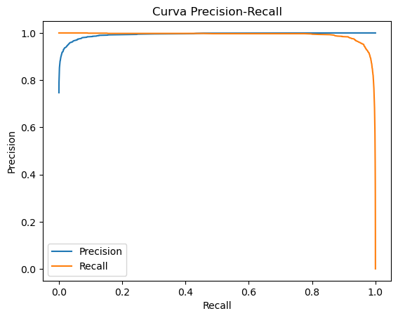

```python
# Obtén las probabilidades de la clase positiva
Y_scores = pipeline.predict_proba(X_test)[:, 1]

# Calcula la curva Precision-Recall
precision, recall, thresholds = precision_recall_curve(Y_test == 'white', Y_scores)

# Calcula el área bajo la curva Precision-Recall
pr_auc = auc(recall, precision)

# Grafica la curva Precision-Recall
plt.plot(thresholds, precision[:-1], label='Precision')
plt.plot(thresholds, recall[:-1], label='Recall')
plt.xlabel('Recall')
plt.ylabel('Precision')
plt.legend()
plt.title('Curva Precision-Recall')
plt.show()
```

```python
from sklearn.metrics import classification_report

Y_pred_prob = Y_scores
Y_pred = np.where(Y_pred_prob > 0.5, 'white', 'red')   #Colocar 1 cuando la probabilidad es > 0.5

# Imprime el reporte de clasificación y la matriz de confusión
print(classification_report(Y_test, Y_pred))
print(confusion_matrix(Y_test, Y_pred))
```

```
              precision    recall  f1-score   support

         red       0.99      1.00      1.00       329
       white       1.00      1.00      1.00       971

    accuracy                           1.00      1300
   macro avg       1.00      1.00      1.00      1300
weighted avg       1.00      1.00      1.00      1300

[[329   0]
 [  3 968]]
```

```python
from sklearn.metrics import classification_report

Y_pred_prob = Y_scores
Y_pred = np.where(Y_pred_prob > 0.1, 'white', 'red')   #Colocar 1 cuando la probabilidad es > 0.1

# Imprime el reporte de clasificación y la matriz de confusión
print(classification_report(Y_test, Y_pred))
print(confusion_matrix(Y_test, Y_pred))
```

```
              precision    recall  f1-score   support

         red       1.00      0.95      0.98       329
       white       0.98      1.00      0.99       971

    accuracy                           0.99      1300
   macro avg       0.99      0.98      0.98      1300
weighted avg       0.99      0.99      0.99      1300

[[314  15]
 [  1 970]]
```

##### **☑️ Area Bajo la Curva (Area Under the Curve - AUC)**

```python
from sklearn.metrics import auc
print(f"auc : {auc(recall, precision)}")
```

```
auc : 0.9999727619218094
```

##### **☑️ Curva ROC**

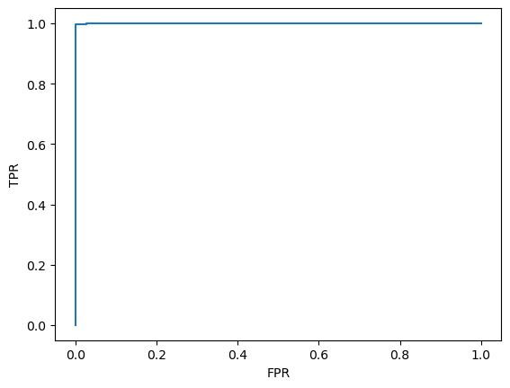

```python
fpr, tpr, threshold = roc_curve(Y_test == 'white', Y_scores)
# ftr = tasa de falsos positivos; tpr = tasa de verdaderos positivos

plt.plot(fpr, tpr)
plt.xlabel('FPR')
plt.ylabel('TPR')
plt.show()
```

```python
print(f"auc : {auc(fpr, tpr)}")
```

```
auc : 0.9999186124040957
```

#### **🔎 Interpretación de Estadisticos de Validación**

[output not shown]

### ⚛️ **Pipeline de Preprocesamiento Mixto basado en ColumnTransformer**

##### 🟢 *Variables categórica = OneHotEncoder / Variables numéricas = MinMaxScaler*

```python
# Eliminación de variables a no usar:
df2 = df.drop("class", axis=1)
X = df2.drop('quality_desc', axis = 1) #X = Todo el dataframe pero sin cancer
Y = df2['quality_desc']

# Definimos las variables categóricas y numéricas
categorical_features = X.select_dtypes(include=['object']).columns
numerical_features = X.select_dtypes(include=['int64', 'float64']).columns

# Creamos pipelines de preprocesamiento
numerical_transformer = Pipeline(steps=[
    ('imputer', SimpleImputer(strategy='mean')),
    ('scaler', MinMaxScaler()) # Valores - media / Desviación estandar
])

categorical_transformer = Pipeline(steps=[
    ('imputer', SimpleImputer(strategy='most_frequent')), #Imputacióin con el mas frecuente (Moda).
    ('onehot', OneHotEncoder(handle_unknown='ignore', sparse_output=False)) #Si llega una categoria desconocida se imputara cero.
])

# Usamos ColumnTransformer para combinar ambas transformaciones
preprocessor = ColumnTransformer(
    transformers=[
        ('num', numerical_transformer, numerical_features),
        ('cat', categorical_transformer, categorical_features)
    ])

preprocessor
```

```
ColumnTransformer(transformers=[('num',
                                 Pipeline(steps=[('imputer', SimpleImputer()),
                                                 ('scaler', MinMaxScaler())]),
                                 Index(['fixed acidity', 'volatile acidity', 'citric acid', 'residual sugar',
       'chlorides', 'free sulfur dioxide', 'total sulfur dioxide', 'density',
       'pH', 'sulphates', 'alcohol'],
      dtype='object')),
                                ('cat',
                                 Pipeline(steps=[('imputer',
                                                  SimpleImputer(strategy='most_frequent')),
                                                 ('onehot',
                                                  OneHotEncoder(handle_unknown='ignore',
                                                                sparse_output=False))]),
                                 Index(['quality'], dtype='object'))])
```

#### 🟢 Creación del Pipeline

```python
# Definimos el pipeline completo
model_pipeline = Pipeline(steps=[('preprocessor', preprocessor)])
```

```python
model_pipeline.fit_transform(X).shape #Hay mas columnas porque cada categoria se vuelve una columna
```

```
(6497, 18)
```

#### 🟢 Entrenamiento de un Modelo con el Pipeline

```python
# Dividimos los datos en entrenamiento y prueba
X_train1, X_test1, Y_train1, Y_test1 = train_test_split(X, Y, test_size=0.2, random_state=42)
# X_train, y_train = Variables de Entrenamiento
# X_test, y_test = Variables de testeo

# Creamos un nuevo pipeline que incluye el preprocesamiento y el modelo
model_pipeline = Pipeline(steps=[('preprocessor', preprocessor),
                                 ('classifier', RandomForestClassifier(n_estimators=100, random_state=42))])
# RandomForestClassifier con 100 arboles y ligado a semilla 42

# Entrenamos el pipeline completo en los datos de entrenamiento
model_pipeline.fit(X_train1, Y_train1)

# Hacemos predicciones en el conjunto de prueba
Y_pred1 = model_pipeline.predict(X_test1)

# Evaluamos el rendimiento del modelo
print(classification_report(Y_test1, Y_pred1))
```

```
              precision    recall  f1-score   support

       Buena       1.00      1.00      1.00       812
    Inferior       1.00      1.00      1.00         6
       Media       1.00      1.00      1.00       445
    Superior       1.00      1.00      1.00        37

    accuracy                           1.00      1300
   macro avg       1.00      1.00      1.00      1300
weighted avg       1.00      1.00      1.00      1300
```

#### **🟢 Analisis de Informe de clasificación**

| Clase | Métricas | Análisis |
| --- | --- | --- |
| Buena | Precision: 1.00 | El modelo clasificó correctamente todas las instancias de esta clase, lo que indica un alto rendimiento. |
|  | Recall: 1.00 | Se identificaron todas las instancias reales de esta clase, lo que demuestra la eficacia del modelo en su detección. |
|  | F1-score: 1.00 | Existe un excelente equilibrio entre precisión y recall para esta clase, lo que sugiere que el modelo es confiable. |
|  | Support: 812 | La cantidad significativa de instancias contribuye a la robustez del modelo y valida su capacidad de generalización. |
| Inferior | Precision: 1.00 | El modelo no cometió errores al clasificar esta clase, lo que refuerza su efectividad. |
|  | Recall: 1.00 | Todas las instancias reales de esta clase fueron identificadas correctamente, lo que indica un alto rendimiento. |
|  | F1-score: 1.00 | Buen equilibrio en el rendimiento, asegurando que no hay falsos positivos ni negativos. |
|  | Support: 6 | Aunque hay pocas instancias, el modelo se desempeñó perfectamente en esta clase. |
| Media | Precision: 1.00 | El modelo mostró un rendimiento excepcional al clasificar todas las instancias correctamente. |
|  | Recall: 1.00 | Todas las instancias reales de esta clase fueron detectadas, lo que resalta la efectividad del modelo. |
|  | F1-score: 1.00 | Indica un balance óptimo entre precisión y recall, reflejando un rendimiento robusto. |
|  | Support: 445 | La cantidad considerable de instancias apoya la validez del modelo en esta categoría. |
| Superior | Precision: 1.00 | El modelo clasificó correctamente todas las instancias de esta clase, lo que demuestra su precisión. |
|  | Recall: 1.00 | Se identificaron todas las instancias reales de esta clase, lo que refuerza la eficacia del modelo. |
|  | F1-score: 1.00 | Refleja un excelente equilibrio en el rendimiento para esta clase. |
|  | Support: 37 | Aunque el número de instancias es pequeño, el modelo logró un desempeño perfecto. |
|  | **Accuracy:** 1.00 | El modelo alcanzó una precisión general del 100% en el conjunto de prueba, lo que es excepcional. |
|  | **Macro Avg:** 1.00 | El promedio de precisión, recall y F1-score indica un rendimiento excelente en todas las clases, sin sesgos. |
|  | **Weighted Avg:** 1.00 | El rendimiento ponderado también muestra un excelente equilibrio en la clasificación, reflejando la eficacia general del modelo. |

```python
model_pipeline
```

```
Pipeline(steps=[('preprocessor',
                 ColumnTransformer(transformers=[('num',
                                                  Pipeline(steps=[('imputer',
                                                                   SimpleImputer()),
                                                                  ('scaler',
                                                                   MinMaxScaler())]),
                                                  Index(['fixed acidity', 'volatile acidity', 'citric acid', 'residual sugar',
       'chlorides', 'free sulfur dioxide', 'total sulfur dioxide', 'density',
       'pH', 'sulphates', 'alcohol'],
      dtype='object')),
                                                 ('cat',
                                                  Pipeline(steps=[('imputer',
                                                                   SimpleImputer(strategy='most_frequent')),
                                                                  ('onehot',
                                                                   OneHotEncoder(handle_unknown='ignore',
                                                                                 sparse_output=False))]),
                                                  Index(['quality'], dtype='object'))])),
                ('classifier', RandomForestClassifier(random_state=42))])
```

```
<BarContainer object of 18 artists>
```

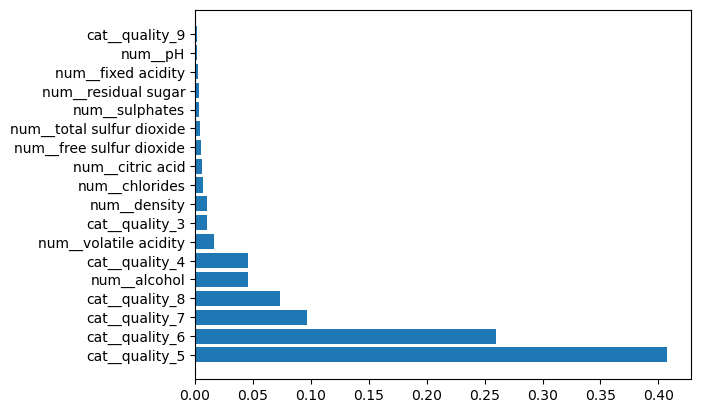

```python
modelo_entrenado=model_pipeline['classifier']
preprocessor_entrenado=model_pipeline['preprocessor']

nombres=preprocessor_entrenado.get_feature_names_out()
importancia=modelo_entrenado.feature_importances_

df_features=pd.DataFrame()
df_features['nombres']=nombres
df_features['importancia']=importancia
df_features=df_features.sort_values('importancia',ascending=False)
plt.barh(df_features.head(20)['nombres'],df_features.head(20)['importancia'])
```

#### **🟢 Guardar el Pipeline Completo (Preprocesador + Modelo)**

Finalmente, guardamos el pipeline completo (incluyendo el modelo entrenado) en un archivo `joblib`.

```python
dump(model_pipeline, '../Modelos/wine_quality_model_multiclass_mixed_preprocessing.joblib')
```

```
['../Modelos/wine_quality_model_multiclass_mixed_preprocessing.joblib']
```

#### **🟢 Cargar procesamiento de Modelo `wine_quality_model_multiclass_mixed_preprocessing`**

```python
model1= load('../Modelos/wine_quality_model_multiclass_mixed_preprocessing.joblib')

# Convertir el diccionario wine_quality_data a una cadena JSON con una indentación de 4 espacios
json_string = json.dumps(wine_quality_data, indent=4)

# Hacer una predicción utilizando el modelo previamente entrenado.
# Se convierte el diccionario wine_quality_data en un DataFrame de pandas para que sea compatible con el modelo.
output = model1.predict(pd.DataFrame(wine_quality_data))

# Imprimir el resultado de la predicción.
# output es un array, y se accede al primer elemento para mostrar el resultado de la predicción.
print(f'Output [Calidad]: {output[0]}')

# Imprimir los datos de entrada en formato JSON.
# Se usa el parámetro sep='\n' para agregar un salto de línea entre el texto "Input" y la cadena JSON.
print('Input:', json_string, sep='\n')
```

```
Output [Calidad]: Buena
Input:
{
    "fixed acidity": [
        6.76
    ],
    "volatile acidity": [
        0.84
    ],
    "citric acid": [
        0.64
    ],
    "residual sugar": [
        3.0
    ],
    "chlorides": [
        0.07
    ],
    "free sulfur dioxide": [
        13
    ],
    "total sulfur dioxide": [
        57
    ],
    "density": [
        1.02
    ],
    "pH": [
        3.33
    ],
    "sulphates": [
        1.78
    ],
    "alcohol": [
        10.85
    ],
    "quality": [
        7
    ]
}
```

#### **🔎 Resumen de Estadisticos de Validación**

##### **☑️ Exactitud (Accuracy)**

```python
exactitud = accuracy_score(Y_test1, Y_pred1)
print(f"Exactitud : {exactitud}")
```

```
Exactitud : 1.0
```

##### **☑️ Precisión (Precision)**

```python
precision = precision_score(Y_test, Y_pred, average='weighted')
print(f"Precisión (Micro): {precision}")
```

[output not shown]

##### **☑️ Sensibilidad (Recall) o Tasa de Verdaderos Positivos**

```python
sensibilidad = recall_score(Y_test, Y_pred, average='weighted')
print(f"Sensibilidad: {sensibilidad}")
```

[output not shown]

##### **☑️ Valor F1**

```python
valor_f1 = f1_score(Y_test, Y_pred, average='weighted')
print(f"Valor F1: {valor_f1}")
```

[output not shown]

#### **🔎 Interpretación de Estadisticos de Validación**

[output not shown]